# The_Void

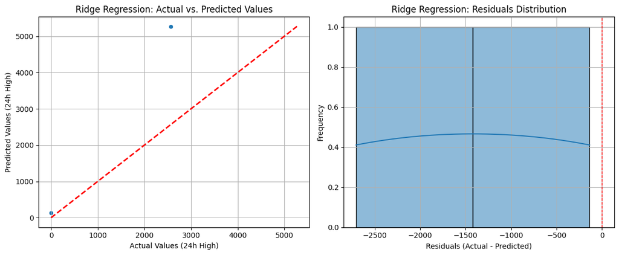

## Understanding Our Prediction Charts

These charts help us evaluate our cryptocurrency price prediction model.

### 1. Actual vs. Predicted Values (Left Chart)

- **Shows:** Compares the **actual** cryptocurrency high prices against our model's **predicted** prices.
- **How to Read:** Each dot is an actual vs. predicted pair. The **red dashed line** signifies perfect predictions.
- **Look For:** Dots close to the red line mean accurate predictions. More scatter means less accuracy.

### 2. Distribution of Prediction Errors (Right Chart)

- **Shows:** The "errors" our model made (Actual Price - Predicted Price).
- **How to Read:** The horizontal axis is the error size. The curve shows how frequently each error size occurred.
- **Look For:** Errors clustered around the **red dashed line at '0'** (meaning small errors). A roughly bell-shaped curve suggests random, unbiased errors.

These visuals help us quickly see how well our model performed.

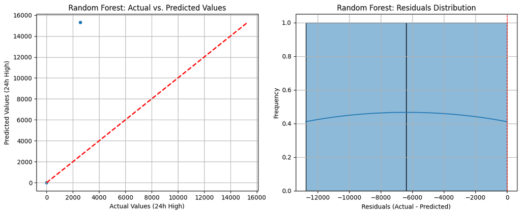

## Understanding the Random Forest Model's Charts

These charts help us understand the performance of our second model, the Random Forest Regressor. We use the same chart types as the Ridge model to ensure a fair comparison.

### 2. Distribution of Prediction Errors (Right Chart)

- **What it shows:** This chart shows the distribution of the model's errors, which are calculated as (Actual Price - Predicted Price). These errors are also called "residuals".
- **How to read it:** The center red line is at "0", which represents a prediction with zero error. The bars show how often the model made errors of a certain size.
- **What to look for:** A good model will have a tall, narrow peak centered at "0", meaning that most of its prediction errors were very small or zero. A wider, flatter curve indicates lower accuracy.

|  | Ridge Regression | Random Forest | Difference | Winner |
| --- | --- | --- | --- | --- |
| Mean Absolute Error (MAE) | 1421.3776 | 6385.1856 | 4963.8081 | Ridge Regression |
| Mean Squared Error (MSE) | 3667632.7584 | 81425334.3476 | 77757701.5892 | Ridge Regression |
| Root Mean Squared Error (RMSE) | 1915.1065 | 9023.5987 | 7108.4923 | Ridge Regression |
| R-squared (R2) | -1.2302 | -48.5134 | -47.2832 | Ridge Regression |

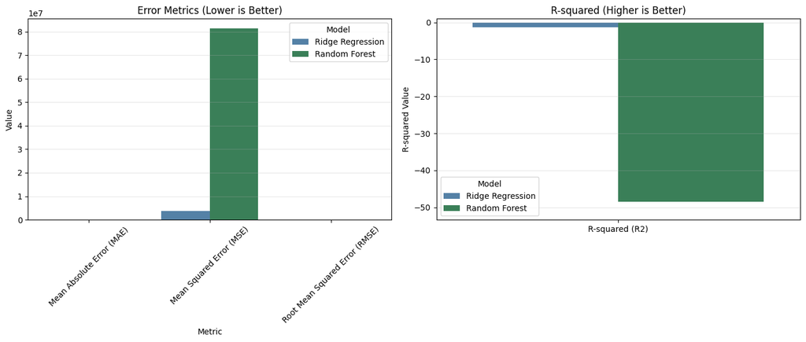

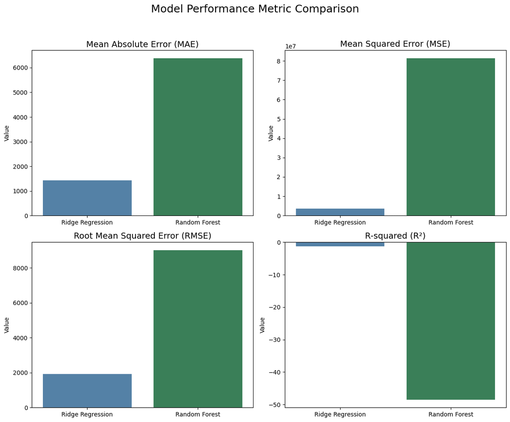

## Final Conclusion: Which Model Is Better?

The analysis is now complete. After building, evaluating, and visualizing both the Ridge Regression and Random Forest models, the final step is to use the comparison table to declare a winner.

### How to Interpret the Results

To decide which model is better, we look at our four key metrics with these simple rules:

- **For error scores (MAE, MSE, RMSE):** Lower is better. A lower score means the model's average prediction error was smaller.
- **For the R-squared (R2) score:** Higher is better. A score closer to 1.0 means the model did a better job of explaining the price's behavior.